# Introduction to Meta-Analysis Workshop

Sarah A. Walker

2025-07-10

# Introduction

Welcome to the 2025 ISSID summer school workshop on beginner meta-analyses! This document is the digital handout for our workshop, and we will walk through a complete worked example to answer the following research question:

**What is the correlation between conscientiousness and academic achievement?**

We will perform an overall meta-analysis, investigate reasons for differences between studies (heterogeneity) using subgroup analysis and meta-regression, and check for potential publication bias. Please keep in mind that this is a completely fabricated data set and as such is perfect for illustration but is terrible for any real world accuracy - real data is messy, complex and so if this doesn’t work perfectly when you come to doing it IRL, please feel free to get in touch (sarah.a.walker@durham.ac.uk)

## Workshop Slides

Slides can be viewed by following this link: [DOWNLOAD](https://www.canva.com/design/DAGsyR48FpM/eeBxEhVT9uglURTe0YeovA/view?utm_content=DAGsyR48FpM&utm_campaign=designshare&utm_medium=link2&utm_source=uniquelinks&utlId=h953158ce76)

# 1. Setup: Loading Packages

First, we need to load the R packages required for our analysis. We will use `meta` and `metafor`.

This code chunk will also install the packages if you don’t have them already.

```r
# Install packages if they are not already installed
if (!require("meta")) install.packages("meta")
if (!require("metafor")) install.packages("metafor")

# Load the packages for use in this session
library(meta)
library(metafor)
```

# 2. Loading the Data

Next, we will load our dataset. A reminder that this is a fictional dataset created for this workshop, containing extracted data from 20 studies.

**Click here to download the dataset (conscientiousness_data.csv)**

**Important:** For the code below to work, the `conscientiousness_data.csv` file must be saved in the same folder as this R Markdown file.

```r
# Read the data from the CSV file
dat <- read.csv("conscientiousness_data.csv")

# Display the first 6 rows to inspect the data
knitr::kable(head(dat), caption = "First 6 Studies in the Dataset")
```

First 6 Studies in the Dataset

| Author | Year | r | n | StudentType | AvgAge |
| --- | --- | --- | --- | --- | --- |
| Smith | 2010 | 0.35 | 150 | University | 20.5 |
| Johnson | 2011 | 0.15 | 210 | HighSchool | 16.2 |
| Williams | 2011 | 0.48 | 120 | University | 21.1 |
| Brown | 2012 | 0.51 | 95 | University | 22.5 |
| Jones | 2013 | 0.12 | 300 | HighSchool | 15.8 |
| Garcia | 2014 | 0.25 | 180 | HighSchool | 17.1 |

# 3. The Overall Meta-Analysis

Now we can perform our main meta-analysis using the `metacor()` function. We specify `random.x = TRUE` to use a random-effects model.

```r
# Run the random-effects meta-analysis
m.gen <- metacor(cor = r,
                 n = n,
                 studlab = Author,
                 data = dat,
                 sm = "COR",
                 method.tau = "REML",
                 random.x = TRUE,
                 method.random.ci = TRUE)

# Print the standard results to the console
print(m.gen, digits = 2)
```

```
## Number of studies: k = 20
## Number of observations: o = 3720
##
##                       COR       95%-CI   z|t  p-value
## Common effect model  0.31 [0.28; 0.34] 21.15 < 0.0001
## Random effects model 0.32 [0.25; 0.39]  9.52 < 0.0001
##
## Quantifying heterogeneity (with 95%-CIs):
##  tau^2 = 0.0190 [0.0090; 0.0441]; tau = 0.1378 [0.0950; 0.2100]
##  I^2 = 82.5% [74.0%; 88.2%]; H = 2.39 [1.96; 2.91]
##
## Test of heterogeneity:
##       Q d.f.  p-value
##  108.57   19 < 0.0001
##
## Details of meta-analysis methods:
## - Inverse variance method
## - Restricted maximum-likelihood estimator for tau^2
## - Q-Profile method for confidence interval of tau^2 and tau
## - Calculation of I^2 based on Q
## - Hartung-Knapp adjustment for random effects model (df = 19)
## - Untransformed correlations
```

# 4. Visualisation: The Forest Plot

The forest plot is the most important visualisation in meta-analysis.

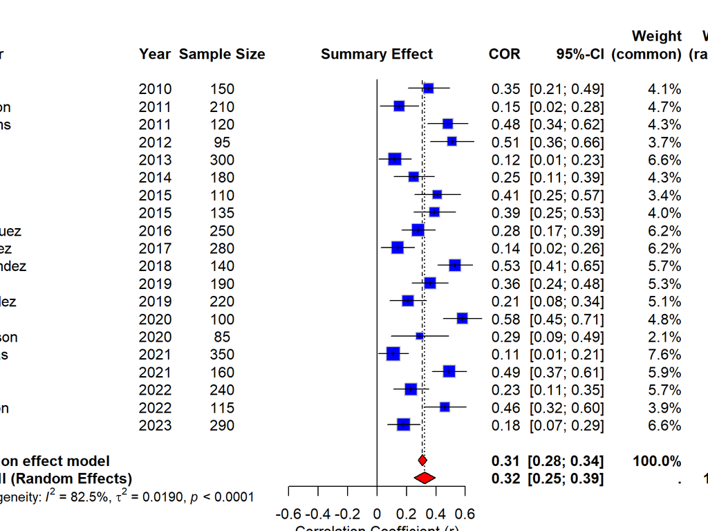

```r
# Generate the forest plot
forest(m.gen,
       sortvar = Year,
       leftcols = c("studlab", "Year", "n"),
       leftlabs = c("Author", "Year", "Sample Size"),
       xlab = "Correlation Coefficient (r)",
       smlab = "Summary Effect",
       text.random = "Overall (Random Effects)",
       col.square = "blue",
       col.diamond = "red")
```

# 5. Investigating Heterogeneity: Subgroup Analysis

Our overall analysis showed high heterogeneity. Let’s see if `StudentType` can explain it.

```r
# Run the subgroup analysis
m.subgroup <- update(m.gen, subgroup = StudentType)

# Print the results
print(m.subgroup, digits = 2)
```

```
## Number of studies: k = 20
## Number of observations: o = 3720
##
##                       COR       95%-CI   z|t  p-value
## Common effect model  0.31 [0.28; 0.34] 21.15 < 0.0001
## Random effects model 0.32 [0.25; 0.39]  9.52 < 0.0001
##
## Quantifying heterogeneity (with 95%-CIs):
##  tau^2 = 0.0190 [0.0090; 0.0441]; tau = 0.1378 [0.0950; 0.2100]
##  I^2 = 82.5% [74.0%; 88.2%]; H = 2.39 [1.96; 2.91]
##
## Test of heterogeneity:
##       Q d.f.  p-value
##  108.57   19 < 0.0001
##
## Results for subgroups (common effect model):
##                            k  COR       95%-CI     Q   I^2
## StudentType = University  11 0.45 [0.41; 0.49] 14.21 29.6%
## StudentType = HighSchool   9 0.18 [0.14; 0.22]  8.33  4.0%
##
## Test for subgroup differences (common effect model):
##                    Q d.f.  p-value
## Between groups 86.03    1 < 0.0001
## Within groups  22.54   18   0.2089
##
## Results for subgroups (random effects model):
##                            k  COR       95%-CI  tau^2    tau
## StudentType = University  11 0.45 [0.39; 0.51] 0.0020 0.0451
## StudentType = HighSchool   9 0.18 [0.13; 0.23] 0.0003 0.0187
##
## Test for subgroup differences (random effects model):
##                    Q d.f.  p-value
## Between groups 67.09    1 < 0.0001
##
## Details of meta-analysis methods:
## - Inverse variance method
## - Restricted maximum-likelihood estimator for tau^2
## - Q-Profile method for confidence interval of tau^2 and tau
## - Calculation of I^2 based on Q
## - Hartung-Knapp adjustment for random effects model (df = 19)
## - Untransformed correlations
```

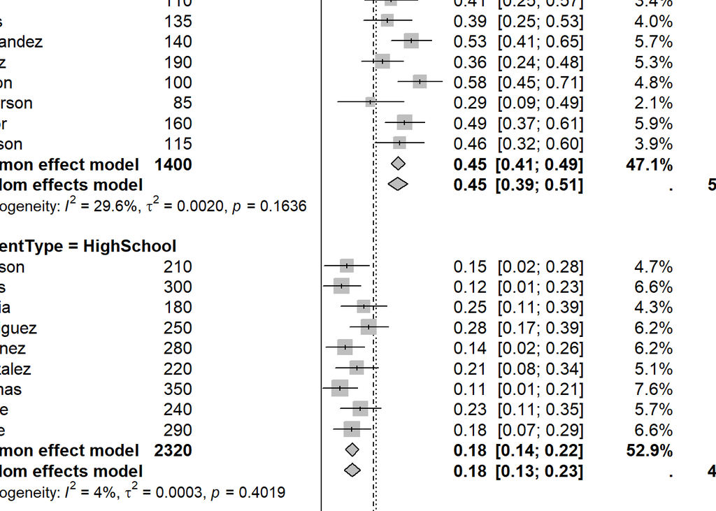

```r
# Generate a forest plot for the subgroup analysis
forest(m.subgroup)
```

# 6. Investigating Heterogeneity: Meta-Regression

Now we test our continuous moderators using `metafor`.

```r
# Calculate effect sizes using escalc() from metafor
dat_es <- escalc(measure = "ZCOR", ri = r, ni = n, data = dat)
```

### Meta-Regression with `AvgAge` (A Significant Predictor)

Let’s test our meaningful moderator: the average age of participants.

```r
# Run the meta-regression model
m.reg_age <- rma(yi, vi, mods = ~ AvgAge, data = dat_es)

# Print the standard results
print(m.reg_age)
```

```
##
## Mixed-Effects Model (k = 20; tau^2 estimator: REML)
##
## tau^2 (estimated amount of residual heterogeneity):     0 (SE = 0.0017)
## tau (square root of estimated tau^2 value):             0
## I^2 (residual heterogeneity / unaccounted variability): 0.00%
## H^2 (unaccounted variability / sampling variability):   1.00
## R^2 (amount of heterogeneity accounted for):            100.00%
##
## Test for Residual Heterogeneity:
## QE(df = 18) = 7.2901, p-val = 0.9874
##
## Test of Moderators (coefficient 2):
## QM(df = 1) = 87.9426, p-val < .0001
##
## Model Results:
##
##          estimate      se     zval    pval    ci.lb    ci.ub
## intrcpt   -0.7980  0.1172  -6.8080  <.0001  -1.0278  -0.5683  ***
## AvgAge     0.0595  0.0063   9.3778  <.0001   0.0471   0.0720  ***
##
## ---
## Signif. codes:  0 '***' 0.001 '**' 0.01 '*' 0.05 '.' 0.1 ' ' 1
```

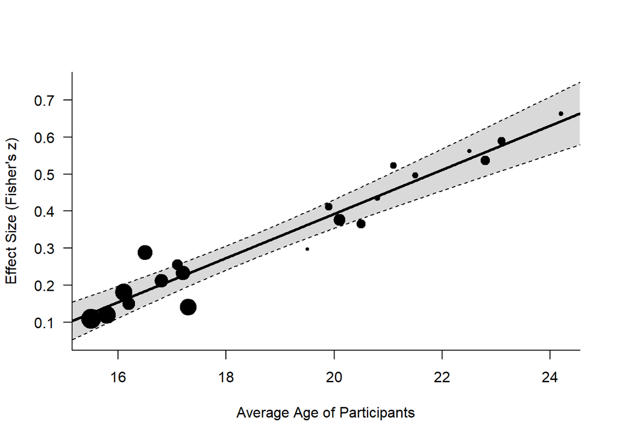

```r
# Create a bubble plot to visualise the results
regplot(m.reg_age,
        mod = "AvgAge",
        xlab = "Average Age of Participants",
        ylab = "Effect Size (Fisher's z)",
        las = 1,
        bty = "l",
        pch = 19)
```

# 7. Checking for Publication Bias

Finally, we check for publication bias visually with a funnel plot and statistically with Egger’s test.

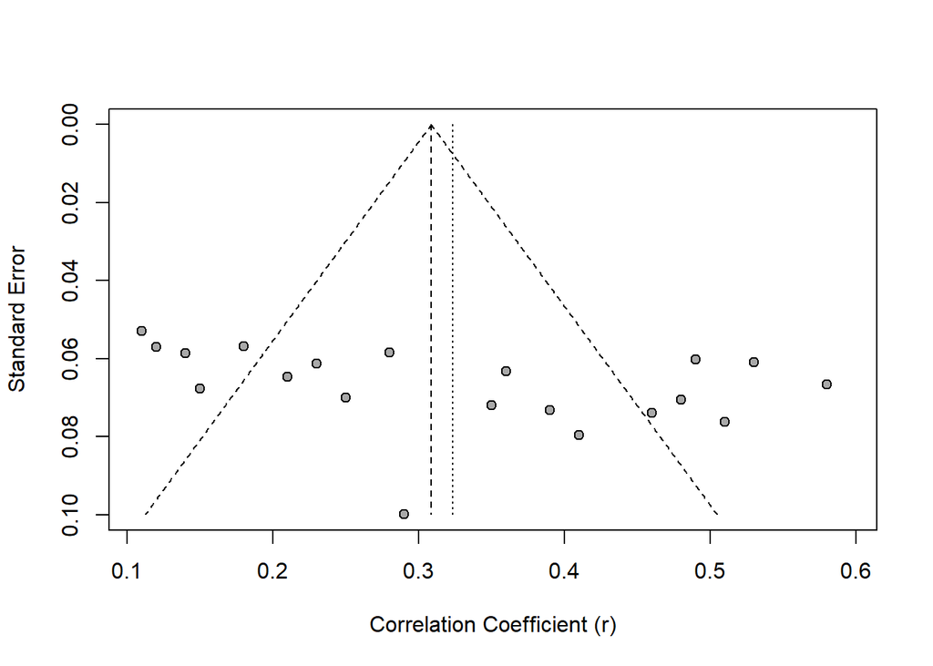

```r
# Create the funnel plot
funnel(m.gen,
       xlab = "Correlation Coefficient (r)")
```

```r
# Run Egger's test for funnel plot asymmetry
metabias(m.gen, method.bias = "Egger")
```

```
## Linear regression test of funnel plot asymmetry
##
## Test result: t = 2.06, df = 18, p-value = 0.0538
## Bias estimate: 7.6071 (SE = 3.6862)
##
## Details:
## - multiplicative residual heterogeneity variance (tau^2 = 4.8778)
## - predictor: standard error
## - weight:    inverse variance
## - reference: Egger et al. (1997), BMJ
```

# Further Learning & Resources

### Key Textbooks

- **“Introduction to Meta-Analysis”** by Borenstein, Hedges, Higgins, & Rothstein. *(This is considered the bible of meta-analysis and is extremely readable).*
- **“Doing Meta-Analysis with R: A Hands-On Guide”** by Harrer, Cuijpers, Furukawa, & Ebert. *(An outstanding, practical guide with all the code you need).* * **[https://bookdown.org/MathiasHarrer/Doing_Meta_Analysis_in_R/]**

### Online Resources

- **[The Cochrane Handbook for Systematic Reviews of Interventions](https://training.cochrane.org/handbook)**: The gold standard for conducting systematic reviews.
- **[The metafor Package Website](https://www.metafor-project.org/)**: The official site for the `metafor` R package has excellent documentation and examples.

## Workshop Slides

Slides can be viewed by following this link: [DOWNLOAD](https://www.canva.com/design/DAGsyR48FpM/eeBxEhVT9uglURTe0YeovA/view?utm_content=DAGsyR48FpM&utm_campaign=designshare&utm_medium=link2&utm_source=uniquelinks&utlId=h953158ce76)